# PD3 Chylak Maciej

##### Wczytanie zbioru danych

```r
df <- OpenML::getOMLDataSet(data.id = 42225)
df <-  df$data
```

##### Dane:

##### Przygotowanie naszego zbioru danych do dalszej analizy. Zamienienie kolumny cut na wartosci numeryczne, skala oceny ciecia

```r
df <- df[, c(1, 2, 3, 4, 5, 6, 8, 9, 10, 7)]

df$cut <- ifelse(df$cut=="Fair", 0, ifelse(df$cut=="Good", 1,
                                           ifelse(df$cut=="Very Good", 2,
                                                  ifelse(df$cut=="Premium", 4, 5))))
colnames(df) <- c(colnames(df[1:6]), "x_mes", "y_mes", "z_mes", "price")
df
```

|  | carat | cut | color | clarity | depth | table | x_mes | y_mes | z_mes | price |
| --- | --- | --- | --- | --- | --- | --- | --- | --- | --- | --- |
| 0 | 0.23 | 5 | E | SI2 | 61.5 | 55.0 | 3.95 | 3.98 | 2.43 | 326 |
| 1 | 0.21 | 4 | E | SI1 | 59.8 | 61.0 | 3.89 | 3.84 | 2.31 | 326 |
| 2 | 0.23 | 1 | E | VS1 | 56.9 | 65.0 | 4.05 | 4.07 | 2.31 | 327 |
| 3 | 0.29 | 4 | I | VS2 | 62.4 | 58.0 | 4.20 | 4.23 | 2.63 | 334 |
| 4 | 0.31 | 1 | J | SI2 | 63.3 | 58.0 | 4.34 | 4.35 | 2.75 | 335 |
| 5 | 0.24 | 2 | J | VVS2 | 62.8 | 57.0 | 3.94 | 3.96 | 2.48 | 336 |
| 6 | 0.24 | 2 | I | VVS1 | 62.3 | 57.0 | 3.95 | 3.98 | 2.47 | 336 |
| 7 | 0.26 | 2 | H | SI1 | 61.9 | 55.0 | 4.07 | 4.11 | 2.53 | 337 |
| 8 | 0.22 | 0 | E | VS2 | 65.1 | 61.0 | 3.87 | 3.78 | 2.49 | 337 |
| 9 | 0.23 | 2 | H | VS1 | 59.4 | 61.0 | 4.00 | 4.05 | 2.39 | 338 |

[output cut: 9990 more lines]

[output not shown]

##### Podzielenie naszego zbioru danych na zbiór treninigowy i walidacyjny

```r
dt <- sort(sample(nrow(df), nrow(df)*.7))
Train <- df[dt, ]
Valid <- df[-dt, ]
```

##### Stworzenie modelu na zbiorze treningowym

```r
model <- ranger::ranger(price~., data=Train)
model
```

```
## Ranger result
##
## Call:
##  ranger::ranger(price ~ ., data = Train)
##
## Type:                             Regression
## Number of trees:                  500
## Sample size:                      37758
## Number of independent variables:  9
## Mtry:                             3
## Target node size:                 5
## Variable importance mode:         none
## Splitrule:                        variance
## OOB prediction error (MSE):       347044
## R squared (OOB):                  0.9781041
```

##### Stworzenie explainera, który posluzy nam pozniej do wyjasnienia modelu

```r
explainer <- explain(model = model,
                     data = Train[, -10],
                     y = Train$price)
```

```
## Preparation of a new explainer is initiated
##   -> model label       :  ranger  (  default  )
##   -> data              :  37758  rows  9  cols
##   -> target variable   :  37758  values
##   -> predict function  :  yhat.ranger  will be used (  default  )
##   -> predicted values  :  No value for predict function target column. (  default  )
##   -> model_info        :  package ranger , ver. 0.12.1 , task regression (  default  )
##   -> predicted values  :  numerical, min =  362.6208 , mean =  3918.014 , max =  18223.75
##   -> residual function :  difference between y and yhat (  default  )
##   -> residuals         :  numerical, min =  -3286.278 , mean =  -0.2318504 , max =  5293.768
##   A new explainer has been created!
```

```r
model_type.dalex_explainer <- DALEXtra::model_type.dalex_explainer
predict_model.dalex_explainer <- DALEXtra::predict_model.dalex_explainer
```

```r
library(corrplot)
res <- cor(df[, c(1, 2, 5, 6, 7, 8, 9)])
round(res, 2)
```

```
##       carat   cut depth table x_mes y_mes z_mes
## carat  1.00 -0.12  0.03  0.18  0.98  0.95  0.95
## cut   -0.12  1.00 -0.22 -0.39 -0.11 -0.11 -0.13
## depth  0.03 -0.22  1.00 -0.30 -0.03 -0.03  0.09
## table  0.18 -0.39 -0.30  1.00  0.20  0.18  0.15
## x_mes  0.98 -0.11 -0.03  0.20  1.00  0.97  0.97
## y_mes  0.95 -0.11 -0.03  0.18  0.97  1.00  0.95
## z_mes  0.95 -0.13  0.09  0.15  0.97  0.95  1.00
```

##### Jak mozemy zauwazyc, szczegolnie zmienne wymiarow diamentu sa z soba silne skorelowane, moze to zaburzyc nieco nasze ostateczne wyniki, gdyz ten model dekompozycji jest szczegolnie wrazliwy na skorelowane zmienne.

##### Wyjasnienie przy pomocy metody ceteris paribus

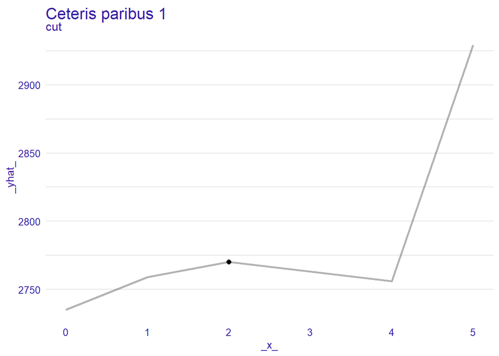

```r
cp_1 <- ceteris_paribus(explainer, observation = Valid[50, -10], variables = "cut")
plot(cp_1) + ggtitle("Ceteris paribus 1")
```

Na pierwszym wykresie mozemy zauwazyc spodziewany wynik, wartosc diamentow rosnie wraz z jakoscia ciecia. Podobnego rozkladu powinnismy sie spodziewac takze przy pozostalych zmiennych

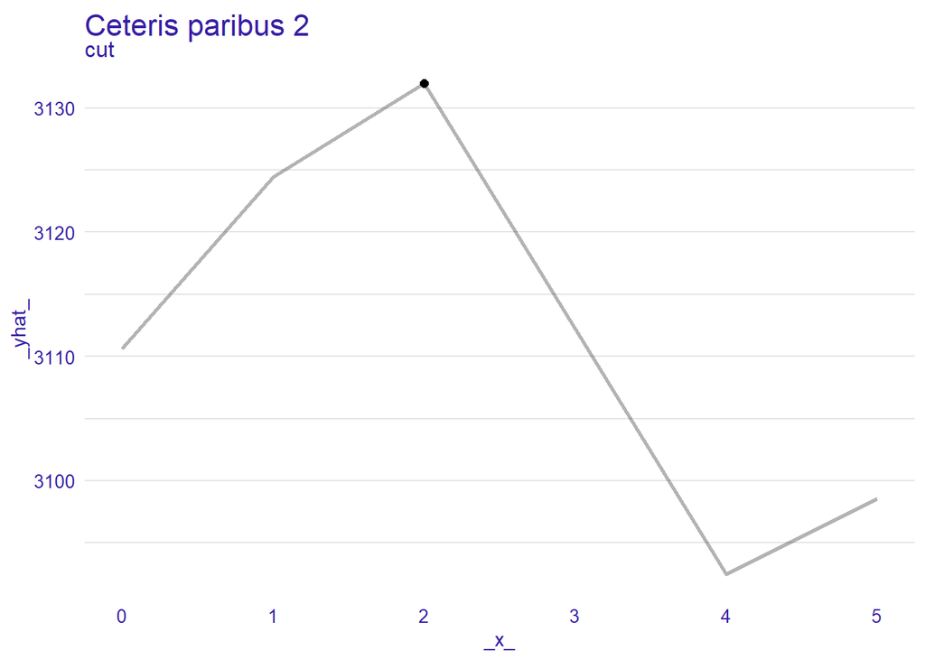

```r
cp_2 <- ceteris_paribus(explainer, observation = Valid[200, -10], variables = "cut")
plot(cp_2) + ggtitle("Ceteris paribus 2")
```

```r
Valid[200, ]
```

|  | carat | cut | color | clarity | depth | table | x_mes | y_mes | z_mes | price |
| --- | --- | --- | --- | --- | --- | --- | --- | --- | --- | --- |
| 678 | 0.74 | 2 | E | VS1 | 63.1 | 58 | 5.75 | 5.73 | 3.62 | 2849 |

[output not shown]

W tym przypadku mozemy zauwazyc dosyc nieoczywista zaleznosc. Wartosc diamentu osiaga swoje maksimum w przypadku gdy jego jakos wynosi 2, natomiast swoje minimum osiaga w punkcie, w ktorym jakos diamentu wynosi 4. Skad wynika taka zaleznosc? Ciezko dokladnie powiedziec, najprawdopodobniej jest ona spowodowana specyfika naszych danych lub z niedokladnosci naszej metody. Na pewno nie powinnismy sugerowac doborem cen w przypadku cech rownych pozostalym cecha naszej wybranej obserwacji, gdyz w dosc nieintuicyjny sposob oszacowalibysmy cene.

Jednak chcialbym rowniez zaznaczyc, ze w wiekszosc przypadkow model zachowal sie w sposob przewidywalny, zanim znalazlem te obserwacje sprawdzilem okolo 20-30 innych i w kazdej z nich wykres wygladal podobnie jak wykres nr 1.